# Practical Machine Learning - Course Project

*Boris Romanciuc*

*November 21, 2018*

## Background

Using devices such as Jawbone Up, Nike FuelBand, and Fitbit it is now possible to collect a large amount of data about personal activity relatively inexpensively. These type of devices are part of the quantified self movement – a group of enthusiasts who take measurements about themselves regularly to improve their health, to find patterns in their behavior, or because they are tech geeks. One thing that people regularly do is quantify how much of a particular activity they do, but they rarely quantify how well they do it. In this project, your goal will be to use data from accelerometers on the belt, forearm, arm, and dumbell of 6 participants. They were asked to perform barbell lifts correctly and incorrectly in 5 different ways. More information is available from the website here: http://web.archive.org/web/20161224072740/http:/groupware.les.inf.puc-rio.br/har (see the section on the Weight Lifting Exercise Dataset).

A short description of the datasets content from the authors’ website:

“Six young health participants were asked to perform one set of 10 repetitions of the Unilateral Dumbbell Biceps Curl in five different fashions: exactly according to the specification (Class A), throwing the elbows to the front (Class B), lifting the dumbbell only halfway (Class C), lowering the dumbbell only halfway (Class D) and throwing the hips to the front (Class E).

**Data**

The training data for this project are available here: https://d396qusza40orc.cloudfront.net/predmachlearn/pml-training.csv

The test data are available here: https://d396qusza40orc.cloudfront.net/predmachlearn/pml-testing.csv

The data for this project come from this source: http://groupware.les.inf.puc-rio.br/har. If you use the document you create for this class for any purpose please cite them as they have been very generous in allowing their data to be used for this kind of assignment.

**Goal**

The goal of your project is to predict the manner in which they did the exercise. This is the “classe” variable in the training set. You may use any of the other variables to predict with. You should create a report describing how you built your model, how you used cross validation, what you think the expected out of sample error is, and why you made the choices you did. You will also use your prediction model to predict 20 different test cases.

## Environment Preparation

First thing we will upload the R libraries that we’ll need for the complete analysis.

```r
library(caret)
library(rpart)
library(randomForest)
library(rpart.plot)
library(rattle)
```

## Data Loading and Preprocesing

In this section we will load from internet the data in two data frames: training and testing one.

```r
train_link <-"https://d396qusza40orc.cloudfront.net/predmachlearn/pml-training.csv"
test_link <- "https://d396qusza40orc.cloudfront.net/predmachlearn/pml-testing.csv"
train_file <- "pml-training.csv"
test_file  <- "pml-testing.csv"

if (!file.exists(train_file)) {
  download.file(train_link, destfile=train_file, method="curl")
}
if (!file.exists(test_file)) {
  download.file(test_link, destfile=test_file, method="curl")
}
```

### Data Reading

Now we are creating two data frames out of our two data csv files and we’ll be checking the dimensions of our data frames.

```r
train_df <- read.csv("pml-training.csv")
test_df <- read.csv("pml-testing.csv")
dim(train_df)
```

```
## [1] 19622   160
```

```r
dim(test_df)
```

```
## [1]  20 160
```

As we can see, the training data frame contains 19622 observations and 160 variables, as the testing data frame contains 20 observations and 160 variables. The “classe” variable in the training set will be used as the outcome to predict.

### Data Cleaninig

Here we will clean the data out of NA and empty values and non significant columns that won’t serve us in our analysis. Also we will remove the first 7 features (columns) since they are identification only variables or time-series or are not numeric, so, in the end, are not that important for our study.

```r
cols <- names(test_df[,colSums(is.na(test_df)) == 0])[8:59]

# We will use only the features used in testing cases.
train_df <- train_df[,c(cols,"classe")]
test_df <- test_df[,c(cols,"problem_id")]

dim(train_df)
```

```
## [1] 19622    53
```

```r
dim(test_df)
```

```
## [1] 20 53
```

## Dataset Partitioning

Now, using the guides from the Machine Learning course, we will split our training data set in two parts: train (70% - for prediction) and test(30% - for validation) of total observations. We will use the train data set for training our predictor and to estimate the sample error for it.

```r
set.seed(2018)

inTrain <- createDataPartition(train_df$classe, p=0.7, list=FALSE)
train_set <- train_df[inTrain,]
test_set <- train_df[-inTrain,]

dim(train_set)
```

```
## [1] 13737    53
```

```r
dim(test_set)
```

```
## [1] 5885   53
```

## Prediction Algorithms

For our analisys in predicting the outcome, we will use two training models (Classification Trees and Random Forests) and will see which one gives a better accuracy.

### Classification Trees

In this model we will use the cross validation technique (**cv**) as to improve the efficiency of the model and to limit the effects of overfitting. Usually, when doing k-fold cross validation, the default setting of **k** is 10 folds, but we will use **k=5** in order to reduce the computing time, although it will have a little and no significant decrease of the accuracy.

```r
set.seed(2018)
train_control <- trainControl(method="cv", number=5)
class_tree_model <- train(classe~., data=train_set, method="rpart", trControl=train_control)
#print(class_tree_model)
print(class_tree_model, digits = 4)
```

```
## CART
##
## 13737 samples
##    52 predictor
##     5 classes: 'A', 'B', 'C', 'D', 'E'
##
## No pre-processing
## Resampling: Cross-Validated (5 fold)
## Summary of sample sizes: 10989, 10991, 10990, 10990, 10988
## Resampling results across tuning parameters:
##
##   cp       Accuracy  Kappa
##   0.03245  0.5221    0.38015
##   0.05991  0.4170    0.21036
##   0.11545  0.3156    0.04758
##
## Accuracy was used to select the optimal model using the largest value.
## The final value used for the model was cp = 0.03245.
```

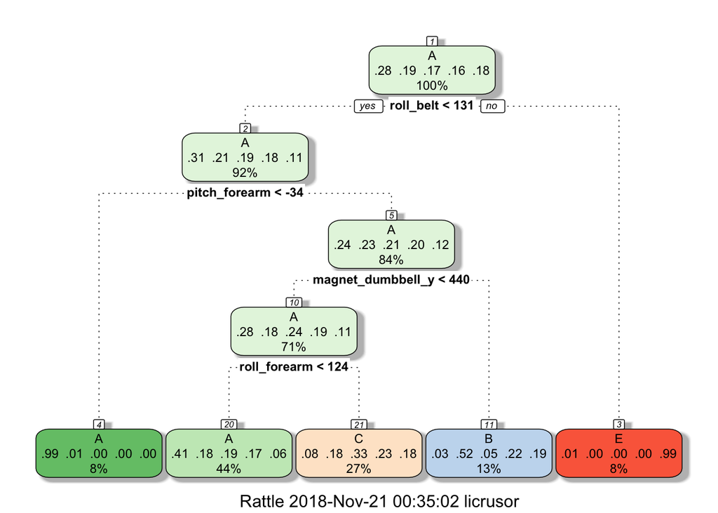

```r
#plot(class_tree_model)
fancyRpartPlot(class_tree_model$finalModel)
```

```r
# predict outcomes using validation set
predict_class_tree <- predict(class_tree_model, test_set)
# Show prediction result
(conf_class_tree <- confusionMatrix(test_set$classe, predict_class_tree))
```

```
## Confusion Matrix and Statistics
##
##           Reference
## Prediction    A    B    C    D    E
##          A 1525   19  125    0    5
##          B  499  369  271    0    0
##          C  464   27  535    0    0
##          D  428  179  357    0    0
##          E  143  156  296    0  487
##
## Overall Statistics
##
##                Accuracy : 0.4955
##                  95% CI : (0.4826, 0.5084)
##     No Information Rate : 0.5198
##     P-Value [Acc > NIR] : 0.9999
##
##                   Kappa : 0.3407
##  Mcnemar's Test P-Value : NA
##
## Statistics by Class:
##
##                      Class: A Class: B Class: C Class: D Class: E
## Sensitivity            0.4985   0.4920  0.33775       NA  0.98984
## Specificity            0.9473   0.8500  0.88584   0.8362  0.88967
## Pos Pred Value         0.9110   0.3240  0.52144       NA  0.45009
## Neg Pred Value         0.6357   0.9197  0.78411       NA  0.99896
## Prevalence             0.5198   0.1274  0.26916   0.0000  0.08360
## Detection Rate         0.2591   0.0627  0.09091   0.0000  0.08275
## Detection Prevalence   0.2845   0.1935  0.17434   0.1638  0.18386
## Balanced Accuracy      0.7229   0.6710  0.61180       NA  0.93975
```

```r
(accuracy_class_tree <- conf_class_tree$overall[1])
```

```
## Accuracy
## 0.495497
```

As we can see from the confusion matrix, the accuracy rate is 0.5 which leads us to the conclusion that using classification trees model does not predict the outcome classe very well.

### Random Forests

So, let’s try now the Random Forests model, as the Classification Trees one did not predict that well on our outcome.

```r
random_forest_model <- train(classe~., data=train_set, method="rf", trControl=train_control, verbose=FALSE)
#print(random_forest_model)
print(random_forest_model, digits = 4)
```

```
## Random Forest
##
## 13737 samples
##    52 predictor
##     5 classes: 'A', 'B', 'C', 'D', 'E'
##
## No pre-processing
## Resampling: Cross-Validated (5 fold)
## Summary of sample sizes: 10990, 10990, 10991, 10990, 10987
## Resampling results across tuning parameters:
##
##   mtry  Accuracy  Kappa
##    2    0.9908    0.9884
##   27    0.9898    0.9871
##   52    0.9843    0.9802
##
## Accuracy was used to select the optimal model using the largest value.
## The final value used for the model was mtry = 2.
```

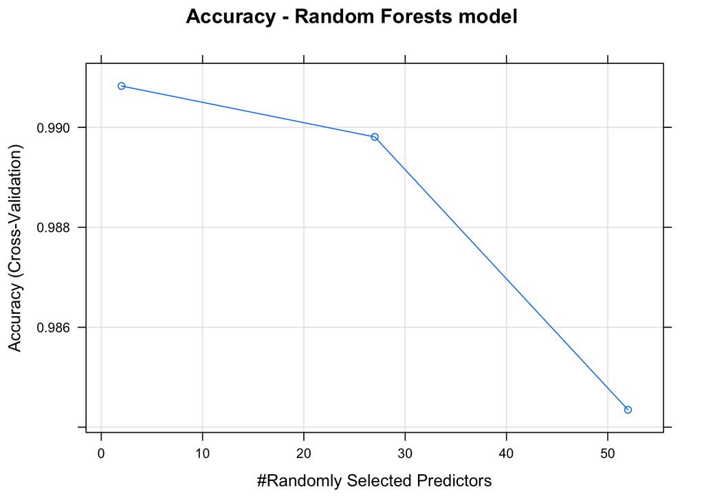

```r
#plot(random_forest_model)
plot(random_forest_model,main="Accuracy - Random Forests model")
```

```r
# predict outcomes using validation set
predict_random_forest <- predict(random_forest_model, test_set)
# Show prediction result
(conf_random_forest <- confusionMatrix(test_set$classe, predict_random_forest))
```

```
## Confusion Matrix and Statistics
##
##           Reference
## Prediction    A    B    C    D    E
##          A 1672    2    0    0    0
##          B    6 1127    6    0    0
##          C    0    9 1015    2    0
##          D    0    0   18  946    0
##          E    0    0    0    2 1080
##
## Overall Statistics
##
##                Accuracy : 0.9924
##                  95% CI : (0.9898, 0.9944)
##     No Information Rate : 0.2851
##     P-Value [Acc > NIR] : < 2.2e-16
##
##                   Kappa : 0.9903
##  Mcnemar's Test P-Value : NA
##
## Statistics by Class:
##
##                      Class: A Class: B Class: C Class: D Class: E
## Sensitivity            0.9964   0.9903   0.9769   0.9958   1.0000
## Specificity            0.9995   0.9975   0.9977   0.9964   0.9996
## Pos Pred Value         0.9988   0.9895   0.9893   0.9813   0.9982
## Neg Pred Value         0.9986   0.9977   0.9951   0.9992   1.0000
## Prevalence             0.2851   0.1934   0.1766   0.1614   0.1835
## Detection Rate         0.2841   0.1915   0.1725   0.1607   0.1835
## Detection Prevalence   0.2845   0.1935   0.1743   0.1638   0.1839
## Balanced Accuracy      0.9980   0.9939   0.9873   0.9961   0.9998
```

```r
(accuracy_random_forest <- conf_random_forest$overall[1])
```

```
##  Accuracy
## 0.9923534
```

As we can see again, now, with the Random Forest model, we are reaching an accuracy of 99.2% using cross-validation with 5 folds.

## Prediction on Testing Set

So, as the second model (Random Forests) is better than the first one (Classificatin Trees), we will use it to predict the outcome variable **classe** for the testing set.

```r
(predict(random_forest_model, test_df))
```

```
##  [1] B A B A A E D B A A B C B A E E A B B B
## Levels: A B C D E
```